# FAS1003: Visualisation des données

# Polices de caractère

## Choisir une police

- On change la police de caractère à travers `theme()`.

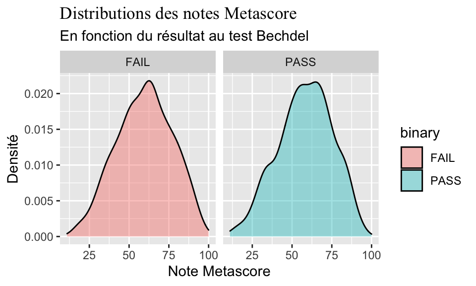

```r
ggplot(data = dat, aes(x = metascore, fill = binary)) +
  geom_density(alpha = .4) +
  facet_wrap(~binary)+
  labs(title = "Distributions des notes Metascore",
       subtitle = "En fonction du résultat au test Bechdel",
       x = "Note Metascore",
       y = "Densité") +
  theme(plot.title = element_text(family = "Times New Roman"))
```

## Utiliser les polices sur votre ordinateur

- Ce ne sont pas toutes les polices qui sont accessibles de facto.
- Le package `extrafont` permet de voir quelles polices de caractère sont disponibles sur votre ordinateur et de les importer dans R.

```r
# install.packages("extrafont")

library(extrafont)
fonts()  # pour voir les polices disponibles
```

## Utiliser les polices sur votre ordinateur

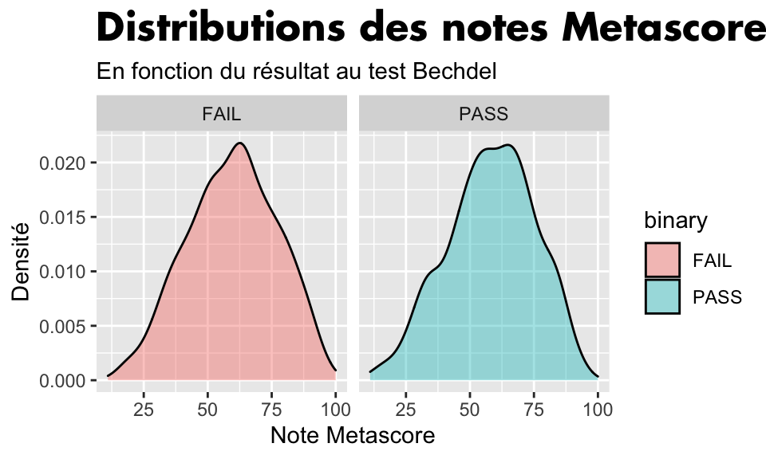

```r
ggplot(data = dat, aes(x = metascore, fill = binary)) +
  geom_density(alpha = .4) +
  facet_wrap(~binary)+
  labs(title = "Distributions des notes Metascore",
       subtitle = "En fonction du résultat au test Bechdel",
       x = "Note Metascore",
       y = "Densité") +
  theme(plot.title = element_text(family = "Futura-Bold", size = 18))
```

## Importer de nouvelles polices

- Téléchargez une police à partir d’internet.
- Utilisez la fonction `font_import()` pour importer toutes les policies qui se trouvent sur votre ordinateur dans R.
- Dans la console, R vous demandera si vous voulez continuez [y/n]. Écrivez y (yes), puis cliquez sur Enter.
- Une fois les polices importées, vous pouvez les utiliser dans vos graphiques.
- Pour savoir leurs noms, faites `fonts()`.

```r
font_import()
```

# Enregistrement des fichiers

## ggsave()

La fonction `ggsave()` permet d’enregistrer vos graphiques sur votre ordinateur (.png, .pdf, etc.).

```r
?ggsave

p = ggplot(data = dat, aes(x = metascore, fill = binary)) +
  geom_density(alpha = .4) +
  scale_fill_discrete(name = "",
                      labels = c("Échec","Réussite")) +
  labs(title = "Distributions des notes Metascore",
       subtitle = "En fonction du résultat au test Bechdel",
       x = "Note Metascore",
       y = "Densité") +
  theme_minimal() +
  theme(axis.title = element_text(hjust = 1),
        legend.position = "",
        plot.title = element_text(size = 16))

ggsave("demo_enregistrer.png", plot = p, width = 8, height = 5)
```

## Un mot sur les chemins

- Quand vous enregistrez un graphique à l’aide de `ggsave()`, le graphique se trouvera au même emplacement que le fichier à partir duquel vous travaillez **puisque vous vous trouvez à l’intérieur d’un R Project.**
- Le R Project définit le répertoire de travail (“working directory”) dans lequel vous travaillez.
- Si vous n’étiez pas à l’intérieur d’un R Project, il faudrait définir le répertoire manuellement, à l’aide de la fonction `setwd()`. Exemple:

```r
setwd("/Users/ordi_de_florence/Documents/cours_FAS-1003")
```